# DA5020 - Practicum II

```r
library(tidyverse)
library(lubridate)
library(mongolite)
library(jsonlite)
library(ggplot2)
library(readr)
```

#### Question 1 — Setup MongoDB

```r
mongo_url <- "mongodb+srv://sb_db:sb_db@da5020-cluster.vajya.mongodb.net/da5020-cluster?retryWrites=true&w=majority"
```

#### Question 2.1 - (5 pts) Open R studio, connect to your mongoDB instance and create a database called Connecticut and a collection called drug_overdose.

```r
db_data <- mongo(collection = "drug_overdose", db = "Connecticut", url = mongo_url)
```

#### Question 2.2 - (5 pts) Use the insert function from the mongolite package to insert the data into the collection directly from the URL. Do not download the file to your computer and load it from there

```r
db_data$insert(read_csv("https://data.ct.gov/api/views/rybz-nyjw/rows.csv?accessType=DOWNLOAD"))
```

```
List of 5
 $ nInserted  : num 5105
 $ nMatched   : num 0
 $ nRemoved   : num 0
 $ nUpserted  : num 0
 $ writeErrors: list()
```

#### Question 2.3 - (5 pts) Display the number of distinct records in the collection.

```r
## count distinct IDs
db_data$distinct("ID", '{}') %>% length()
```

```
[1] 5105
```

#### Question 2.4 - (10 pts) Calculate the number of deaths in the deathcounty. Sort the results in descending order based on the total and limit your results to the top 5 counties. Display the results using a suitable chart (using ggplot)

```r
top_death_county <- db_data$aggregate('[{"$group":{
                      "_id":"$DeathCounty",
                      "count": {"$sum":1}}},
                    {"$sort": {"count": -1}},
                    {"$limit": 5}]')
top_death_county
```

|  | _id | count |
| --- | --- | --- |
| 1 | HARTFORD | 1233 |
| 2 | NEW HAVEN | 1107 |
| 3 | NA | 1100 |
| 4 | FAIRFIELD | 623 |
| 5 | NEW LONDON | 368 |

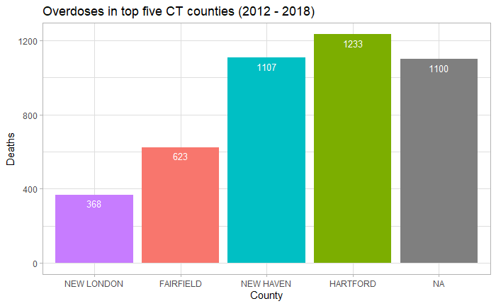

```r
top_death_county %>%
  ggplot(aes(x    = reorder(`_id`, count),
             y    = count,
             fill = `_id`)) +
  geom_col() +
  labs(title = "Overdoses in top five CT counties (2012 - 2018)",
       x     = "County",
       y     = "Deaths") +
  theme_light() +
  guides(fill = FALSE) +
  geom_text(aes(label = count),
            vjust = 1.6,
            color = "white",
            size  = 3.5)
```

Hartford county has the highest number of deaths.

#### Question 2.5 - (10 pts) Select the county with the highest deaths (from #4 above) and perform the following:

```r
## a. Show the ratio of male to female deaths.
hartford_mf <-
  db_data$aggregate('[
          { "$match": {"DeathCounty" : "HARTFORD"}},
          { "$group":{ "_id":"$Sex",
                       "count": {"$sum":1} }}]')  ## filter county and count sex groups
hartford_mf %>%
  pivot_wider(names_from =`_id`, values_from = count) %>%
  summarise("male/female ratio" = Male / Female)
```

| male/female ratio |
| --- |
| 2.932907 |

```r
## b. Calculate the total Fentanyl-related cause of death
## (use the cod field, hint: use string matching or regular expressions).

## regex search for fentanyl in COD, ignoring case
db_data$count('{ "COD" : { "$regex" : "fentanyl", "$options" : "i" }}')
```

```
[1] 2222
```

#### Question 2.6 - (10 pts) Analyze the ages (and you can use age groups), is this issue prevalent within certain age groups.

```r
## get case counts by age
cases_by_age <- db_data$aggregate('[{"$group":{
                      "_id":"$Age",
                      "count": {"$sum":1}}},
                    {"$sort": {"_id": 1}}]')

## define age groups
cases_by_age %>% group_by(`< 18`    = cut(`_id`, breaks = seq(0, 17, 17)),
                          `18 - 30` = cut(`_id`, breaks = seq(17, 30, 13)),
                          `31 - 45` = cut(`_id`, breaks = seq(30, 45, 15)),
                          `46 - 60` = cut(`_id`, breaks = seq(45, 60, 15)),
                          `> 60`    = cut(`_id`, breaks = seq(60, 100, 40))) %>%
  ## convert to character
  ungroup() %>% mutate_at(vars(`< 18`, `18 - 30`,
                               `31 - 45`, `46 - 60`,
                               `> 60`), funs(as.character)) %>%
  ## generate age group column
  mutate(age_groups = coalesce(`< 18`, `18 - 30`, `31 - 45`,
                               `46 - 60`, `> 60`)) %>%
  ## count cases per group
  group_by(age_groups) %>% summarise(n = sum(count)) %>%

  ## fix group names
  mutate(age_groups = c("< 18", "18 - 30",
                        "31 - 45", "46 - 60",
                        "> 60", "NA"))
```

[output not shown]

| age_groups | n |
| --- | --- |
| < 18 | 13 |
| 18 - 30 | 1125 |
| 31 - 45 | 1845 |
| 46 - 60 | 1806 |
| > 60 | 313 |
| NA | 3 |

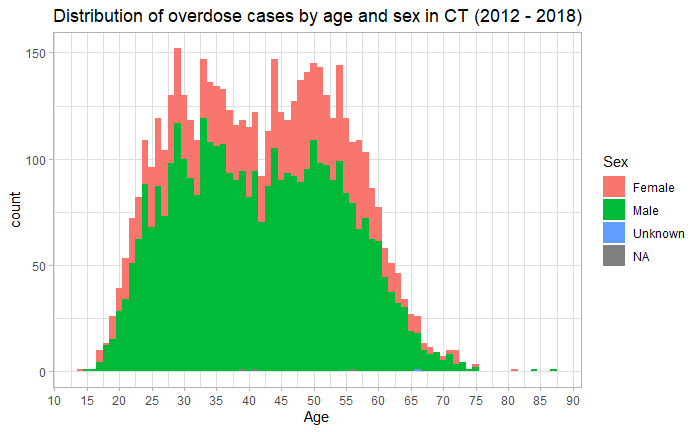

```r
  #### ALTERNATE APPROACH ####
db_data$find(fields = '{"ID" : true, "Age" : true, "Sex" : true}') %>%
  ggplot(aes(x    = Age,
             fill = Sex)) +
  geom_histogram(binwidth = 1) +
  scale_x_continuous(breaks = seq(0, 100, 5)) +
  labs(title = "Distribution of overdose cases by age and sex in CT (2012 - 2018)") + theme_light()
```

**The issue is prevalent in a wide range of ages from 20 - 60, with a bi-modal distribution peaking at ages 30 and 50. Cases are much more prevalent among males.**

#### Question 2.7 - (15 pts) Calculate the total monthly cases of heroin, cocaine, and fentanyl in 2018 and display the results using a line chart (using ggplot). Explain the results.

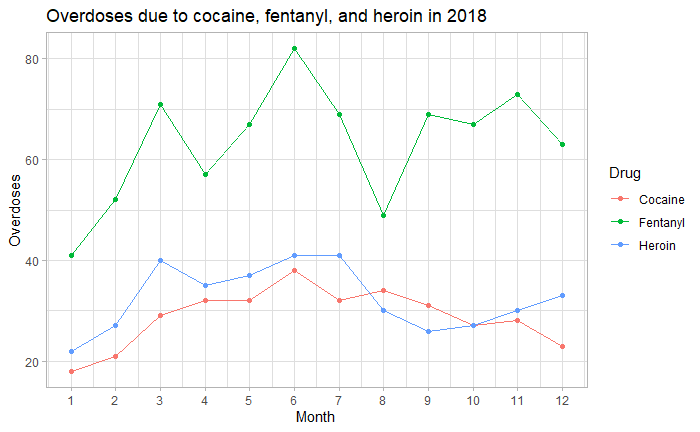

```r
## get 2018 cases
cases_2018 <-
  db_data$find(
    query = '{"Date" : { "$regex" : "2018", "$options" : "i" }}',
    fields = '{"Date" : true, "Heroin" : true, "Cocaine" : true, "Fentanyl" : true, "_id" : false}'
  ) %>% as_tibble()

cases_2018 %>%
  ## extract month
  mutate(month = month(mdy_hms(Date))) %>%
  ## tidy
  pivot_longer(cols      = Fentanyl:Cocaine,
               names_to  = "Drug",
               values_to = "Overdose") %>%
  ## remove NAs
  drop_na(Overdose) %>%
  ## group by month and drug
  group_by(month, Drug) %>%
  ## count entries of cases/drug/month
  summarise(n = n()) %>%
  ## plot
  ggplot(aes(x     = month,
             y     = n,
             color = Drug)) +
  geom_line() +
  geom_point() +
  scale_x_continuous(breaks = seq(1, 12, 1)) +
  labs(title = "Overdoses due to cocaine, fentanyl, and heroin in 2018",
       x     = "Month",
       y     = "Overdoses") +
  theme_light()
```

**Overdose cases of cocaine, fentanyl, and heroin are at their lowest point at the beginning of the year and peak in June.** #### Question 3 - Build one additional query (of your choice) to retrieve data from MongoDB into a data frame. Prepare supporting visualizations and explain your analysis. You can use/reference supporting data where necessary.

```r
## get entries for all drugs and some demographic info
all_drugs <-
  db_data$find(
    fields = '{"ID" : true, "Date" : true, "Race" : true, "Sex" : true,
    "DeathCounty" : true, "Heroin" : true, "Cocaine" : true, "Fentanyl" : true,
    "Hydrocodone" : true, "Methadone" : true, "Ethanol" : true,
    "Oxymorphone" : true, "Tramad" : true, "Morphine_NotHeroin" : true,
    "OpiateNOS" : true, "FentanylAnalogue" : true, "Fentanyl" : true,
    "Benzodiazepine" : true, "Oxycodone" : true, "Hydromorphone" : true,
    "_id" : false}'
  ) %>% as_tibble()
```

We can have a look at cases by drug type

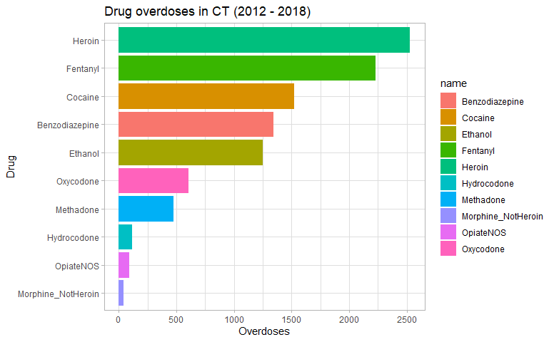

```r
all_drugs %>%
  ## pick some interesting drugs
  select(Heroin, Hydrocodone, Benzodiazepine, Oxycodone, Methadone,
         Ethanol, Morphine_NotHeroin, OpiateNOS, Cocaine, Fentanyl) %>%
  ## longer is neater
  pivot_longer(1:10) %>%
  ## NAs aren't helpful here
  drop_na() %>%
  ## group by drug
  group_by(name) %>%
  ## count each group
  summarise(n = n()) %>%
  ## plot
  ggplot(aes(x    = reorder(name, n),
             y    = n,
             fill = name)) +
  geom_bar(stat = "identity") +
  coord_flip() +
  theme_light() +
  labs(title = "Drug overdoses in CT (2012 - 2018)",
       x     = "Drug",
       y     = "Overdoses")
```

**The number of alcohol overdoses is more than oxycodone and methadone combined.**

**What does county-level overdose by drug look like?**

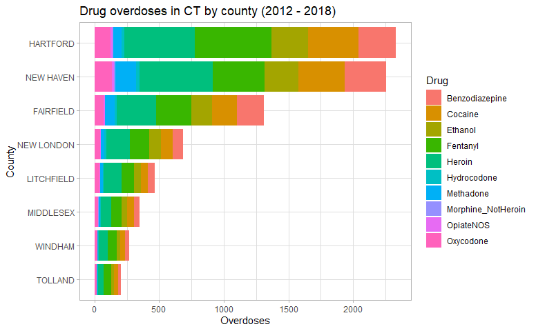

```r
all_drugs %>%
  ## subset county and drugs
  select(DeathCounty, Heroin, Hydrocodone, Benzodiazepine, Oxycodone, Methadone,
         Ethanol, Morphine_NotHeroin, OpiateNOS, Cocaine, Fentanyl) %>%
  ## remove 1 aberrant entry with "USA" as county
  na_if("USA") %>%
  ## longer data
  pivot_longer(Heroin:Fentanyl,
               names_to = "Drug") %>%
  ## remove NA values
  drop_na(DeathCounty, value) %>%
  ## group by county and drug
  group_by(DeathCounty, Drug) %>%
  ## count cases by drug per county
  summarise(n = n()) %>%
  ## plot
  ggplot(aes(x    = reorder(DeathCounty, n),
             y    = n,
             fill = Drug)) +
  geom_bar(stat = "identity") +
  coord_flip() +
  labs(title = "Drug overdoses in CT by county (2012 - 2018)",
       x     = "County",
       y     = "Overdoses") +
  theme_light()
```

**Methadone overdoses appear to be much higher in New Haven than any other county**

**A closer look at Methadone overdoses:**

```r
all_drugs %>%
  ## same pipeline as before
    select(DeathCounty, Heroin, Hydrocodone, Benzodiazepine, Oxycodone, Methadone,
           Ethanol, Morphine_NotHeroin, OpiateNOS, Cocaine, Fentanyl) %>%
    na_if("USA") %>%
    pivot_longer(Heroin:Fentanyl,
                 names_to = "Drug") %>%
    drop_na(DeathCounty, value) %>%
    group_by(DeathCounty, Drug) %>%
    summarise(n = n()) %>%
  ## view methadone cases
  filter(Drug == "Methadone") %>%
  arrange(desc(n))
```

| DeathCounty | Drug | n |
| --- | --- | --- |
| NEW HAVEN | Methadone | 161 |
| FAIRFIELD | Methadone | 72 |
| HARTFORD | Methadone | 67 |
| NEW LONDON | Methadone | 25 |
| LITCHFIELD | Methadone | 22 |
| MIDDLESEX | Methadone | 14 |
| WINDHAM | Methadone | 9 |
| TOLLAND | Methadone | 2 |

**New Haven Methadone overdoses are more than twice as high as the next county**

What role does race play?

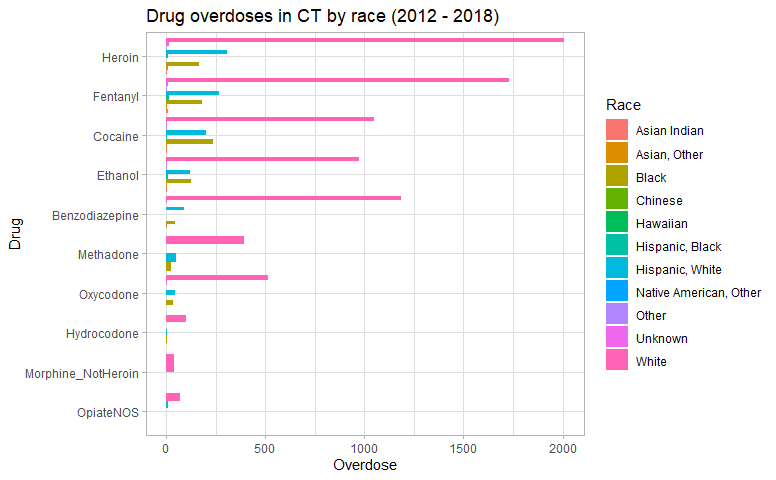

```r
all_drugs %>%
  ## same selection as before, but now with race
  select(Race, Heroin, Hydrocodone, Benzodiazepine, Oxycodone, Methadone,
         Ethanol, Morphine_NotHeroin,  OpiateNOS, Cocaine, Fentanyl) %>%
  drop_na(Race)  %>%
  pivot_longer(Heroin:Fentanyl,
               names_to  = "Drug",
               values_to = "Overdose") %>%
  drop_na() %>%
  ## group by race and drug instead of just drug
  group_by(Race, Drug) %>%
  summarise(n  = n()) %>%
  ## plot
  ggplot(aes(x = reorder(Drug, n),
             y = n)) +
  geom_bar(aes(fill = Race),
           position = "dodge",
           stat     = "identity") +
  theme_light() +
  labs(title = "Drug overdoses in CT by race (2012 - 2018)",
       x     = "Drug",
       y     = "Overdose") +
  coord_flip()
```

**White people are overwhelmingly affected by these overdoses in each category.**

**Let’s have a look at county level**

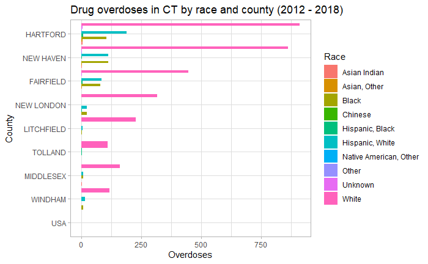

```r
all_drugs %>%
  ## remove NAs
  drop_na(Race, DeathCounty) %>%
  ## group by race and county
  group_by(Race, DeathCounty) %>%
  ## count cases by race per county
  summarise(n = n()) %>%
  ## plot
  ggplot(aes(x = reorder(DeathCounty, n),
             y = n)) +
  geom_bar(aes(fill = Race),
           position = "dodge",
           stat     = "identity") +
  coord_flip() +
  labs(title = "Drug overdoses in CT by race and county (2012 - 2018)",
       x     = "County",
       y     = "Overdoses") +
  theme_light()
```

**County-level data reflects the State-wide data with White people being most affected in all counties.**

We saw in question 2.5a that males are 3x more affected by overdoses than females.  
Let’s look more closely at that using a per-drug resolution.

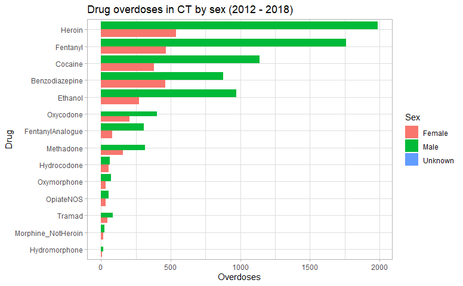

```r
all_drugs %>%
  ## pick a few more drugs along with sex
  select(Sex, Heroin, Hydrocodone, Hydromorphone, Benzodiazepine, Oxycodone,
         Methadone, Ethanol, Oxymorphone, Tramad, Morphine_NotHeroin,
         OpiateNOS, FentanylAnalogue, Cocaine, Fentanyl) %>%
  ## missing sex data will not be helpful
  drop_na(Sex)  %>%
  ## tidy
  pivot_longer(cols      = Heroin:Fentanyl,
               names_to  = "Drug",
               values_to = "Overdose") %>%
  ## drop entries which do not have an overdose
  drop_na() %>%
  ## group by sex and drug
  group_by(Sex, Drug) %>%
  ## count overdose by sex per drug
  summarise(n = n()) %>%
  ## plot
  ggplot(aes(x = reorder(Drug, n), y = n)) +
  geom_bar(aes(fill = Sex), position = "dodge", stat = "identity") +
  theme_light() + labs(title = "Drug overdoses in CT by sex (2012 - 2018)",
       x     = "Drug",
       y     = "Overdoses") + coord_flip()
```

**Per drug resolution of overdoses by sex show males are significantly more affected**

What does cumulative overdoses over time look like?

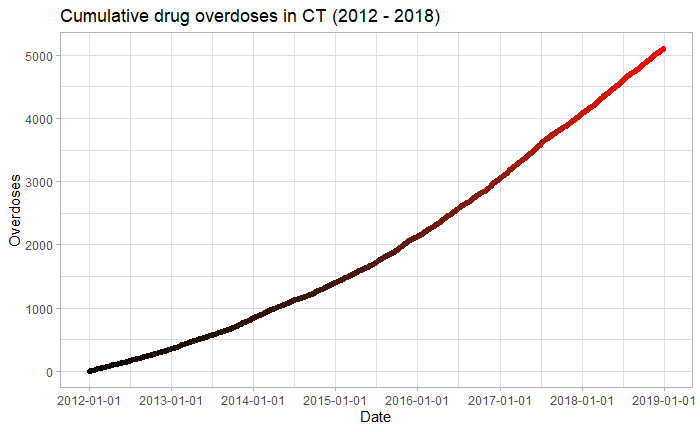

```r
all_drugs %>%
  ## get ymd from date
  mutate(year_date = ymd(mdy_hms(Date))) %>%
  ## sort by ymd
  arrange(year_date) %>%
  ## add a column for cumulative cases
  mutate(total = row_number()) %>%
  ## group by ymd
  group_by(year_date) %>%
  ## the last entry of each group indicates the total for that ymd
  slice(n()) %>%
  ## plot
  ggplot(aes(x     = year_date,
             y     = total,
             color = total)) +
  geom_point() +
  scale_x_date(breaks = "year") +
  labs(title = "Cumulative drug overdoses in CT (2012 - 2018)",
       x     = "Date",
       y     = "Overdoses") +
  theme_light() +
  scale_color_gradient(low = "black", high = "red") +
  guides(color = FALSE)
```

**There has a been a steady uptrend in overdoses since 2012.**

**Looks quite linear. Can we fit a model?**

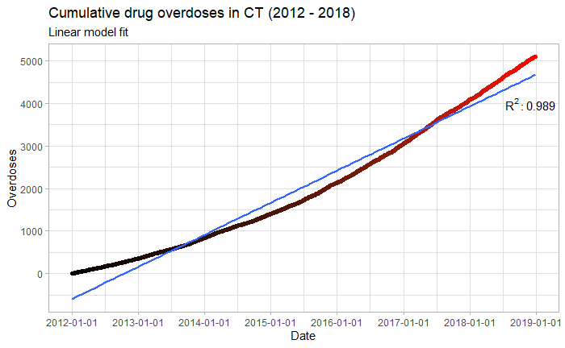

```r
od_tbl <-
  ## same pipeline as before
  all_drugs %>%
  mutate(year_date = ymd(mdy_hms(Date))) %>%
  arrange(year_date) %>%
  mutate(total = row_number()) %>%
  group_by(year_date) %>%
  slice(n())

## perform linear regression
od_model <-
  summary(lm(total ~ seq_along(total), od_tbl))

## plot
od_tbl %>%
  ggplot(aes(x     = year_date,
             y     = total,
             color = total)) +
  geom_point() +
  scale_x_date(breaks = "year") +
  labs(title    = "Cumulative drug overdoses in CT (2012 - 2018)",
       subtitle = "Linear model fit",
       x        = "Date",
       y        = "Overdoses") +
  theme_light() +
  scale_color_gradient(low = "black",
                       high = "red") +
  guides(color = FALSE) +
  ## add fitting line
  geom_smooth(formula = "y ~ x", method = "lm", na.rm = TRUE) +
  ## overlay R-squared
  annotate("text",
           x = ymd("2018-12-01"),
           y = 4000,
           label = parse(
             text = paste0("R^2: ", round(od_model$r.squared, 3))))
```

**The R-squared value indicates a good linear fit.**

How have overdoses increase at the county level?

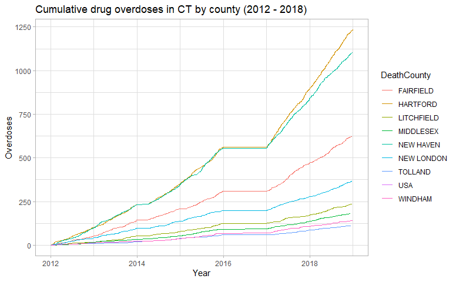

```r
all_drugs %>%
  ## extract ymd from date
  mutate(year_date = ymd(mdy_hms(Date))) %>%
  ## group by county
  group_by(DeathCounty) %>%
  ## sort by ymd
  arrange(year_date) %>%
  ## count cumulative cases by county
  mutate(county_count = row_number()) %>%
  ## remove NAs in deathcounty
  drop_na(DeathCounty) %>%
  ## plot
  ggplot(aes(x     = year_date,
             y     = county_count,
             color = DeathCounty)) +
  geom_line() +
  labs(title = "Cumulative drug overdoses in CT by county (2012 - 2018)",
       x     = "Year",
       y     = "Overdoses") +
  theme_light()
```

**Hartford and New Haven have had the steepest increase in cases over time.**  
**There may be a missing data in 2016, indicated by a flattening of the curve for that year.**

*A closer look at 2016:*

```r
all_drugs %>% filter(year(mdy_hms(Date)) == "2016") %>% head()
```

| ID | Date | Fentanyl | Hydrocodone | Benzodiazepine | Sex | Race | DeathCounty | Cocaine | Heroin | Oxycodone | Methadone | Oxymorphone | Ethanol | FentanylAnalogue | OpiateNOS | Tramad | Morphine_NotHeroin | Hydromorphone |
| --- | --- | --- | --- | --- | --- | --- | --- | --- | --- | --- | --- | --- | --- | --- | --- | --- | --- | --- |
| 16-0165 | 03/13/2016 12:00:00 AM | NA | NA | NA | Female | White | NA | Y | Y | NA | NA | NA | NA | NA | NA | NA | NA | NA |
| 16-0208 | 03/31/2016 12:00:00 AM | Y | NA | NA | Male | White | NA | NA | Y | NA | NA | NA | NA | NA | NA | NA | NA | NA |
| 16-0028 | 01/13/2016 12:00:00 AM | NA | NA | Y | Male | Black | NA | NA | Y | NA | NA | NA | NA | NA | NA | NA | NA | NA |
| 16-0065 | 01/30/2016 12:00:00 AM | NA | NA | NA | Male | White | NA | NA | Y | NA | NA | NA | Y | NA | NA | NA | NA | NA |
| 16-0889 | 12/20/2016 12:00:00 AM | Y | NA | Y | Male | White | NA | NA | Y | NA | NA | NA | NA | NA | NA | NA | NA | NA |
| 16-0688 | 10/07/2016 12:00:00 AM | Y | NA | NA | Male | White | NA | NA | Y | NA | NA | NA | NA | NA | NA | NA | NA | NA |

While there are entries for 2016, data for DeathCounty is not entered.

```r
all_drugs %>% filter(year(mdy_hms(Date)) == "2016") %>%
  distinct(DeathCounty)
```

| DeathCounty |
| --- |
| NA |

**Only NA values are shown for DeathCounty in 2016.**